# Supplementary Analyses

Mariola Paruzel-Czachura, Cillian McHugh

05 February, 2023

# H1 Gender Differences

## Internalization

### Internalization Ns

Table 1:

*Total samples for each country for Internalization analysis*

|  | Total N | n Female | N male |
| --- | --- | --- | --- |
| Argentina | 721 | 498 | 223 |
| Australia | 2138 | 1101 | 1037 |
| Austria | 1368 | 731 | 637 |
| Bangladesh | 396 | 217 | 179 |
| Belgium | 1145 | 468 | 677 |
| Bolivia | 29 | 17 | 12 |
| Brazil | 1811 | 1086 | 725 |
| Bulgaria | 647 | 424 | 223 |
| Canada | 954 | 579 | 375 |
| Chile | 97 | 63 | 34 |
| China | 1030 | 505 | 525 |
| Colombia | 1249 | 784 | 465 |
| Costa Rica | 25 | 9 | 16 |
| Croatia | 507 | 264 | 243 |
| Cuba | 43 | 22 | 21 |
| Denmark | 566 | 280 | 286 |
| Dominican Republic | 36 | 29 | 7 |
| Ecuador | 148 | 82 | 66 |
| El Salvador | 28 | 15 | 13 |
| Finland | 653 | 317 | 336 |
| France | 1107 | 606 | 501 |
| Germany | 1537 | 772 | 765 |
| Ghana | 188 | 59 | 129 |
| Greece | 635 | 222 | 413 |
| Guatemala | 48 | 21 | 27 |
| Honduras | 24 | 17 | 7 |
| Hungary | 501 | 258 | 243 |
| India | 604 | 248 | 356 |
| Iraq | 543 | 263 | 280 |
| Ireland | 737 | 494 | 243 |
| Israel | 1250 | 634 | 616 |
| Italy | 1262 | 679 | 583 |
| Japan | 1150 | 589 | 561 |
| Latvia | 1003 | 633 | 370 |
| Mexico | 1243 | 626 | 617 |
| Morocco | 623 | 333 | 290 |
| Nepal | 345 | 183 | 162 |
| Netherlands | 1286 | 598 | 688 |
| New Zealand | 508 | 255 | 253 |
| Nicaragua | 16 | 10 | 6 |
| Nigeria | 555 | 274 | 281 |
| North Macedonia | 684 | 386 | 298 |
| Norway | 526 | 284 | 242 |
| Pakistan | 477 | 256 | 221 |
| Panama | 18 | 12 | 6 |
| Paraguay | 16 | 14 | 2 |
| Peru | 91 | 41 | 50 |
| Philippines | 508 | 256 | 252 |
| Poland | 1806 | 895 | 911 |
| Puerto Rico* | 2 | 1 | 1 |
| Romania | 997 | 504 | 493 |
| Russia | 557 | 294 | 263 |
| Senegal | 302 | 109 | 193 |
| Serbia | 758 | 561 | 197 |
| Singapore | 542 | 280 | 262 |
| Slovakia | 1254 | 626 | 628 |
| South Africa | 585 | 438 | 147 |
| South Korea | 491 | 231 | 260 |
| Spain | 1077 | 353 | 724 |
| Sweden | 1552 | 631 | 921 |
| Switzerland | 1056 | 537 | 519 |
| Taiwan | 833 | 419 | 414 |
| Turkey | 1436 | 735 | 701 |
| Ukraine | 577 | 303 | 274 |
| United Arab Emirates | 184 | 89 | 95 |
| United Kingdom | 547 | 280 | 267 |
| United States | 1489 | 762 | 727 |
| Uruguay | 49 | 34 | 15 |
| Venezuela | 96 | 54 | 42 |

*Note.* * = sample too small to be included in analysis below

### Internalization Table

Table 2:

*Gender differences in Internalization for each Country*

|  | mean F | SD F | mean M | SD M | t | df | p | d |
| --- | --- | --- | --- | --- | --- | --- | --- | --- |
| Argentina | 8.44 | 1.44 | 8.02 | 1.44 | -3.42 | 392.5 | .001* | 0.09 |
| Australia | 7.77 | 1.78 | 7.12 | 1.78 | -8.51 | 2133.61 | < .001** | 0.13 |
| Austria | 8.09 | 1.58 | 7.68 | 1.58 | -4.78 | 1341.04 | < .001** | 0.09 |
| Bangladesh | 8.76 | 1.33 | 8.54 | 1.33 | -1.66 | 388.82 | .098 | 0.33 |
| Belgium | 8.12 | 1.37 | 7.51 | 1.37 | -7.02 | 1067.52 | < .001** | 0 |
| Bolivia | 8.05 | 1.56 | 8.52 | 1.56 | 0.86 | 25.61 | .398 | -0.45 |
| Brazil | 8.67 | 1.4 | 8.05 | 1.4 | -8.06 | 1329.01 | < .001** | 0.05 |
| Bulgaria | 8.33 | 1.75 | 8.07 | 1.75 | -1.83 | 457.45 | .067 | 0.29 |
| Canada | 8.12 | 1.67 | 7.58 | 1.67 | -4.63 | 753.2 | < .001** | 0.17 |
| Chile | 8.36 | 1.4 | 7.8 | 1.4 | -1.86 | 66.54 | .067 | 0.47 |
| China | 7.58 | 1.28 | 7.61 | 1.28 | 0.41 | 1027.93 | .680 | 0 |
| Colombia | 8.46 | 1.51 | 8.09 | 1.51 | -3.9 | 874.38 | < .001** | 0.11 |
| Costa Rica | 8.24 | 1.6 | 7.95 | 1.6 | -0.47 | 14.4 | .648 | -0.74 |
| Croatia | 7.91 | 1.79 | 7.19 | 1.79 | -4.55 | 503.29 | < .001** | 0.16 |
| Cuba | 8.87 | 1.57 | 8.91 | 1.57 | 0.09 | 40.68 | .927 | 0.14 |
| Denmark | 6.76 | 1.83 | 7.38 | 1.83 | 4.01 | 563.82 | < .001** | -0.05 |
| Dominican Republic | 8.99 | 1.32 | 7.66 | 1.32 | -1.92 | 7.79 | .092 | -0.25 |
| Ecuador | 8.21 | 1.41 | 8.2 | 1.41 | -0.02 | 137.1 | .986 | -0.17 |
| El Salvador | 8.53 | 1.4 | 8.4 | 1.4 | -0.24 | 24.71 | .812 | 0.09 |
| Finland | 7.95 | 1.48 | 7.29 | 1.48 | -5.28 | 648.24 | < .001** | 0.31 |
| France | 7.15 | 1.69 | 6.77 | 1.69 | -3.77 | 1064.53 | < .001** | 0.07 |
| Germany | 7.39 | 2.02 | 7.09 | 2.02 | -3.07 | 1527.98 | .002* | 0.18 |
| Ghana | 5.51 | 1.52 | 5.55 | 1.52 | 0.18 | 122.77 | .855 | 0.12 |
| Greece | 8.59 | 1.19 | 7.93 | 1.19 | -6.06 | 547.77 | < .001** | 0.34 |
| Guatemala | 9.19 | 1.07 | 8.23 | 1.07 | -2.39 | 44.36 | .021* | -0.35 |
| Honduras | 9.15 | 1.3 | 8.69 | 1.3 | -0.88 | 12.98 | .394 | 0.53 |
| Hungary | 8.39 | 1.49 | 7.69 | 1.49 | -5.01 | 489.28 | < .001** | 0.22 |
| India | 8.46 | 1.48 | 8.44 | 1.48 | -0.15 | 567.24 | .884 | 0.05 |
| Iraq | 7.81 | 1.69 | 7.69 | 1.69 | -0.84 | 539.78 | .403 | -0.05 |
| Ireland | 8.7 | 1.18 | 8.25 | 1.18 | -4.48 | 437.97 | < .001** | 0.29 |
| Israel | 8.46 | 1.43 | 8.05 | 1.43 | -4.78 | 1217.88 | < .001** | 0.2 |
| Italy | 7.7 | 1.64 | 7.15 | 1.64 | -5.88 | 1228.75 | < .001** | 0.07 |
| Japan | 6.4 | 1.59 | 6.02 | 1.59 | -4.26 | 1147.97 | < .001** | 0.08 |
| Latvia | 7.36 | 1.74 | 6.43 | 1.74 | -7.76 | 719.78 | < .001** | 0.41 |
| Mexico | 8.47 | 1.48 | 8.16 | 1.48 | -3.52 | 1229.42 | < .001** | -0.04 |
| Morocco | 8.09 | 1.77 | 7.72 | 1.77 | -2.59 | 605.58 | .010* | 0.1 |
| Nepal | 8.66 | 1.36 | 8.14 | 1.36 | -3.34 | 324.22 | .001* | 0.18 |
| Netherlands | 8.05 | 1.36 | 7.42 | 1.36 | -7.86 | 1282.99 | < .001** | 0.27 |
| New Zealand | 7.23 | 1.74 | 8.03 | 1.74 | 5.46 | 500.89 | < .001** | 0.01 |
| Nicaragua | 8.18 | 1.78 | 8.63 | 1.78 | 0.52 | 11.41 | .615 | -0.35 |
| Nigeria | 8.76 | 1.43 | 8.58 | 1.43 | -1.46 | 552.89 | .144 | -0.11 |
| North Macedonia | 8.44 | 1.46 | 7.84 | 1.46 | -4.8 | 578.15 | < .001** | 0.09 |
| Norway | 8.32 | 1.47 | 7.52 | 1.47 | -5.98 | 499.72 | < .001** | 0.31 |
| Pakistan | 8.52 | 1.51 | 7.95 | 1.51 | -3.64 | 423.13 | < .001** | -0.02 |
| Panama | 8.4 | 1.93 | 8.63 | 1.93 | 0.29 | 13.6 | .773 | -0.2 |
| Paraguay | 8.2 | 1.5 | 7.3 | 1.5 | -1.12 | 1.75 | .394 | 0.84 |
| Peru | 7.9 | 1.64 | 8.27 | 1.64 | 1.09 | 83.37 | .280 | -0.15 |
| Peurto Rico | 9.8 | - | 9 | - | - | - | - | - |
| Philippines | 8.29 | 1.7 | 8.05 | 1.7 | -1.64 | 505.35 | .101 | 0.03 |
| Poland | 7.7 | 1.76 | 7.17 | 1.76 | -6.42 | 1802.64 | < .001** | 0.22 |
| Romania | 7.98 | 1.8 | 7.66 | 1.8 | -2.84 | 994.59 | .005* | 0.08 |
| Russia | 7.71 | 1.86 | 7.15 | 1.86 | -3.58 | 549.08 | < .001** | 0.17 |
| Senegal | 8.55 | 1.63 | 8.24 | 1.63 | -1.62 | 224.95 | .107 | 0.02 |
| Serbia | 8.37 | 1.62 | 7.9 | 1.62 | -3.38 | 334.08 | .001* | 0.29 |
| Singapore | 7.6 | 1.7 | 7.19 | 1.7 | -2.85 | 539.92 | .005* | -0.14 |
| Slovakia | 7.71 | 1.66 | 7.14 | 1.66 | -6.08 | 1251.82 | < .001** | 0.31 |
| South Africa | 8.89 | 1.16 | 8.28 | 1.16 | -4.54 | 208.36 | < .001** | 0.36 |
| South Korea | 6.81 | 1.6 | 6.69 | 1.6 | -0.79 | 482.19 | .429 | -0.09 |
| Spain | 8.47 | 1.3 | 7.97 | 1.3 | -5.59 | 788.67 | < .001** | 0.31 |
| Sweden | 8.51 | 1.25 | 7.83 | 1.25 | -9.54 | 1512.41 | < .001** | 0.31 |
| Switzerland | 7.52 | 1.75 | 6.83 | 1.75 | -6.55 | 1053.76 | < .001** | 0.06 |
| Taiwan | 6.71 | 1.58 | 6.61 | 1.58 | -0.95 | 830.97 | .341 | -0.15 |
| Turkey | 8.2 | 1.61 | 7.76 | 1.61 | -4.8 | 1401.97 | < .001** | 0.19 |
| Ukraine | 7.96 | 1.57 | 7.14 | 1.57 | -6.19 | 565.45 | < .001** | 0.05 |
| United Arab Emirates | 8.66 | 1.39 | 8.26 | 1.39 | -1.79 | 181.23 | .075 | 0.21 |
| United Kingdom | 8.85 | 1.13 | 8.2 | 1.13 | -5.99 | 514.83 | < .001** | 0.32 |
| United States | 7.63 | 1.96 | 7.03 | 1.96 | -6.11 | 1484.33 | < .001** | -0.22 |
| Uruguay | 8.24 | 1.39 | 7.89 | 1.39 | -0.61 | 20.36 | .551 | 0.14 |
| Venezuela | 8.37 | 1.98 | 8.45 | 1.98 | 0.22 | 93.99 | .829 | -0.12 |

*Note.* * = sig. at p < .05; ** = sig. at p < .001

## Symbolization

### Symbolization Ns

Table 3:

*Total samples for each country for Symbolization analysis*

|  | Total N | n Female | N male |
| --- | --- | --- | --- |
| Argentina | 721 | 498 | 223 |
| Australia | 2142 | 1103 | 1039 |
| Austria | 1389 | 738 | 651 |
| Bangladesh | 399 | 220 | 179 |
| Belgium | 1156 | 471 | 685 |
| Bolivia | 29 | 17 | 12 |
| Brazil | 1819 | 1091 | 728 |
| Bulgaria | 654 | 428 | 226 |
| Canada | 956 | 580 | 376 |
| Chile | 97 | 63 | 34 |
| China | 1030 | 505 | 525 |
| Colombia | 1261 | 792 | 469 |
| Costa Rica | 25 | 9 | 16 |
| Croatia | 511 | 266 | 245 |
| Cuba | 43 | 22 | 21 |
| Denmark | 566 | 280 | 286 |
| Dominican Republic | 36 | 29 | 7 |
| Ecuador | 148 | 82 | 66 |
| El Salvador | 28 | 15 | 13 |
| Finland | 653 | 317 | 336 |
| France | 1112 | 610 | 502 |
| Germany | 1581 | 794 | 787 |
| Ghana | 205 | 67 | 138 |
| Greece | 635 | 222 | 413 |
| Guatemala | 48 | 21 | 27 |
| Honduras | 24 | 17 | 7 |
| Hungary | 505 | 260 | 245 |
| India | 626 | 262 | 364 |
| Iraq | 551 | 264 | 287 |
| Ireland | 741 | 496 | 245 |
| Israel | 1251 | 636 | 615 |
| Italy | 1271 | 683 | 588 |
| Japan | 1157 | 591 | 566 |
| Latvia | 1003 | 633 | 370 |
| Mexico | 1251 | 628 | 623 |
| Morocco | 641 | 340 | 301 |
| Nepal | 349 | 186 | 163 |
| Netherlands | 1296 | 602 | 694 |
| New Zealand | 509 | 256 | 253 |
| Nicaragua | 16 | 10 | 6 |
| Nigeria | 562 | 279 | 283 |
| North Macedonia | 699 | 392 | 307 |
| Norway | 531 | 284 | 247 |
| Pakistan | 483 | 258 | 225 |
| Panama | 18 | 12 | 6 |
| Paraguay | 16 | 14 | 2 |
| Peru | 91 | 41 | 50 |
| Philippines | 511 | 257 | 254 |
| Poland | 1806 | 895 | 911 |
| Puerto Rico* | 2 | 1 | 1 |
| Romania | 1001 | 507 | 494 |
| Russia | 557 | 294 | 263 |
| Senegal | 326 | 118 | 208 |
| Serbia | 768 | 567 | 201 |
| Singapore | 544 | 281 | 263 |
| Slovakia | 1260 | 630 | 630 |
| South Africa | 629 | 468 | 161 |
| South Korea | 494 | 234 | 260 |
| Spain | 1089 | 357 | 732 |
| Sweden | 1564 | 635 | 929 |
| Switzerland | 1056 | 537 | 519 |
| Taiwan | 833 | 419 | 414 |
| Turkey | 1445 | 739 | 706 |
| Ukraine | 577 | 303 | 274 |
| United Arab Emirates | 187 | 91 | 96 |
| United Kingdom | 548 | 280 | 268 |
| United States | 1494 | 767 | 727 |
| Uruguay | 49 | 34 | 15 |
| Venezuela | 96 | 54 | 42 |

*Note.* * = sample too small to be included in analysis below

### Symbolization Table

Table 4:

*Gender differences in Symbolization for each Country*

|  | mean F | SD F | mean M | SD M | t | df | p | d |
| --- | --- | --- | --- | --- | --- | --- | --- | --- |
| Argentina | 5.67 | 2.26 | 5.47 | 2.26 | -1.1 | 425.98 | .272 | 0.09 |
| Australia | 5.59 | 1.98 | 5.32 | 1.98 | -3 | 2115.11 | .003* | 0.13 |
| Austria | 5.08 | 2.07 | 4.9 | 2.07 | -1.7 | 1374.66 | .089 | 0.09 |
| Bangladesh | 6.32 | 2.08 | 5.6 | 2.08 | -3.22 | 362.43 | .001* | 0.33 |
| Belgium | 4.75 | 1.84 | 4.75 | 1.84 | -0.01 | 1050.5 | .989 | 0 |
| Bolivia | 5.89 | 2.05 | 6.77 | 2.05 | 1.18 | 24.87 | .250 | -0.45 |
| Brazil | 6.11 | 2.07 | 5.99 | 2.07 | -1.16 | 1472.52 | .247 | 0.06 |
| Bulgaria | 5.48 | 2.28 | 4.82 | 2.28 | -3.37 | 433.96 | .001* | 0.28 |
| Canada | 5.2 | 1.8 | 4.88 | 1.8 | -2.51 | 733.9 | .012* | 0.17 |
| Chile | 5.93 | 2.15 | 4.88 | 2.15 | -2.1 | 61.15 | .039* | 0.47 |
| China | 6.44 | 1.51 | 6.44 | 1.51 | -0.07 | 1025.55 | .944 | 0 |
| Colombia | 5.87 | 2.26 | 5.61 | 2.26 | -1.93 | 960.85 | .054 | 0.11 |
| Costa Rica | 4.58 | 1.85 | 6.21 | 1.85 | 1.86 | 21.02 | .077 | -0.74 |
| Croatia | 5.2 | 2.09 | 4.87 | 2.09 | -1.83 | 509 | .067 | 0.16 |
| Cuba | 7.25 | 2.66 | 6.91 | 2.66 | -0.44 | 40.94 | .665 | 0.14 |
| Denmark | 4.47 | 2.05 | 4.58 | 2.05 | 0.59 | 563.91 | .558 | -0.05 |
| Dominican Republic | 6.83 | 2.36 | 7.37 | 2.36 | 0.83 | 17.32 | .417 | -0.25 |
| Ecuador | 6.04 | 2.34 | 6.43 | 2.34 | 1.03 | 141.47 | .306 | -0.17 |
| El Salvador | 4.96 | 2.95 | 4.68 | 2.95 | -0.23 | 23.96 | .818 | 0.09 |
| Finland | 4.1 | 1.97 | 3.48 | 1.97 | -3.99 | 648.76 | < .001** | 0.31 |
| France | 5.37 | 1.89 | 5.24 | 1.89 | -1.12 | 1067.69 | .262 | 0.07 |
| Germany | 4.61 | 2.22 | 4.22 | 2.22 | -3.57 | 1578.1 | < .001** | 0.18 |
| Ghana | 4.61 | 2.35 | 4.42 | 2.35 | -0.53 | 137.06 | .597 | 0.08 |
| Greece | 4.97 | 1.73 | 4.38 | 1.73 | -4.1 | 465.34 | < .001** | 0.34 |
| Guatemala | 5.56 | 2.28 | 6.38 | 2.28 | 1.18 | 44.64 | .243 | -0.35 |
| Honduras | 7.88 | 1.85 | 6.94 | 1.85 | -1.16 | 11.6 | .271 | 0.53 |
| Hungary | 5.68 | 2.12 | 5.23 | 2.12 | -2.41 | 502.54 | .016* | 0.21 |
| India | 5.08 | 2.47 | 5.04 | 2.47 | -0.19 | 532.77 | .851 | 0.02 |
| Iraq | 5.8 | 1.79 | 5.85 | 1.79 | 0.31 | 548.9 | .756 | -0.03 |
| Ireland | 5.17 | 2.01 | 4.57 | 2.01 | -3.75 | 482.47 | < .001** | 0.29 |
| Israel | 5.17 | 2.04 | 4.79 | 2.04 | -3.34 | 1247.88 | .001* | 0.19 |
| Italy | 5.95 | 1.94 | 5.8 | 1.94 | -1.38 | 1243.15 | .168 | 0.08 |
| Japan | 4.51 | 1.68 | 4.37 | 1.68 | -1.3 | 1146.15 | .193 | 0.08 |
| Latvia | 5.17 | 1.87 | 4.39 | 1.87 | -6.28 | 758.91 | < .001** | 0.41 |
| Mexico | 6.11 | 2.3 | 6.18 | 2.3 | 0.54 | 1248.11 | .592 | -0.03 |
| Morocco | 5.31 | 2.27 | 5.1 | 2.27 | -1.13 | 625.2 | .257 | 0.09 |
| Nepal | 6.76 | 1.74 | 6.44 | 1.74 | -1.63 | 336.05 | .105 | 0.18 |
| Netherlands | 5.06 | 1.91 | 4.53 | 1.91 | -4.87 | 1282.91 | < .001** | 0.27 |
| New Zealand | 5.4 | 1.9 | 5.35 | 1.9 | -0.27 | 506.78 | .785 | 0.02 |
| Nicaragua | 5.42 | 3.22 | 6.43 | 3.22 | 0.65 | 11.68 | .527 | -0.35 |
| Nigeria | 7.11 | 2 | 7.32 | 2 | 1.28 | 555.87 | .203 | -0.11 |
| North Macedonia | 5.42 | 2.18 | 5.23 | 2.18 | -1.15 | 660.82 | .249 | 0.09 |
| Norway | 5.08 | 1.88 | 4.51 | 1.88 | -3.55 | 525.3 | < .001** | 0.31 |
| Pakistan | 5.99 | 1.89 | 6.02 | 1.89 | 0.15 | 464.07 | .880 | -0.01 |
| Panama | 5.57 | 2.29 | 6.07 | 2.29 | 0.32 | 7.26 | .758 | -0.2 |
| Paraguay | 6.51 | 2.65 | 4.5 | 2.65 | -2.33 | 6.88 | .054 | 0.84 |
| Peru | 5.7 | 2.19 | 6.04 | 2.19 | 0.71 | 87.2 | .478 | -0.15 |
| Peurto Rico | 8.8 | - | 6.8 | - | - | - | - | - |
| Philippines | 6.57 | 2.03 | 6.51 | 2.03 | -0.34 | 507.11 | .730 | 0.03 |
| Poland | 5.68 | 1.96 | 5.25 | 1.96 | -4.73 | 1796.3 | < .001** | 0.22 |
| Romania | 6.05 | 2.14 | 5.89 | 2.14 | -1.28 | 993.51 | .201 | 0.08 |
| Russia | 4.26 | 2.14 | 3.9 | 2.14 | -1.96 | 545.13 | .050 | 0.17 |
| Senegal | 5.47 | 2.28 | 5.55 | 2.28 | 0.31 | 268.65 | .758 | -0.03 |
| Serbia | 4.51 | 2.27 | 3.86 | 2.27 | -3.73 | 377.33 | < .001** | 0.3 |
| Singapore | 5.44 | 1.88 | 5.7 | 1.88 | 1.65 | 541.55 | .100 | -0.14 |
| Slovakia | 5.81 | 2.04 | 5.19 | 2.04 | -5.49 | 1257.86 | < .001** | 0.31 |
| South Africa | 6.05 | 2.13 | 5.23 | 2.13 | -4.07 | 266.99 | < .001** | 0.38 |
| South Korea | 6.03 | 1.54 | 6.15 | 1.54 | 0.95 | 476.26 | .340 | -0.09 |
| Spain | 5.39 | 1.98 | 4.77 | 1.98 | -4.89 | 711.96 | < .001** | 0.32 |
| Sweden | 5.07 | 2.02 | 4.43 | 2.02 | -6.11 | 1359.93 | < .001** | 0.32 |
| Switzerland | 4.95 | 1.97 | 4.84 | 1.97 | -0.91 | 1053.9 | .361 | 0.06 |
| Taiwan | 4.97 | 1.75 | 5.25 | 1.75 | 2.21 | 821.58 | .027* | -0.15 |
| Turkey | 6.18 | 2.39 | 5.73 | 2.39 | -3.74 | 1439.36 | < .001** | 0.2 |
| Ukraine | 4.44 | 2.11 | 4.32 | 2.11 | -0.64 | 545.09 | .521 | 0.05 |
| United Arab Emirates | 6.14 | 1.81 | 5.71 | 1.81 | -1.5 | 183.14 | .135 | 0.22 |
| United Kingdom | 4.85 | 2.09 | 4.2 | 2.09 | -3.75 | 545.99 | < .001** | 0.32 |
| United States | 5.84 | 2 | 6.31 | 2 | 4.27 | 1450.77 | < .001** | -0.22 |
| Uruguay | 5.42 | 2.28 | 5.11 | 2.28 | -0.45 | 27.87 | .655 | 0.14 |
| Venezuela | 5.93 | 2.73 | 6.23 | 2.73 | 0.58 | 92.37 | .560 | -0.12 |

*Note.* * = sig. at p < .05; ** = sig. at p < .001

# Testing for Country Effects

## Internalization

Initial testing revealed that for Internalization, allowing intercepts to vary with Country significantly improved the predictive power of the model $\chi$<sup>2</sup>(1) = 5564, *p* < .001.

Table 5:

*Internalization basic descriptives by Country*

|  | mean | sd | min | max | len |
| --- | --- | --- | --- | --- | --- |
| ARE | 8.36 | 1.61 | 2.00 | 10.00 | 313 |
| ARG | 8.31 | 1.50 | 2.00 | 10.00 | 721 |
| AUS | 7.45 | 1.79 | 1.00 | 10.00 | 2161 |
| AUT | 7.87 | 1.61 | 0.40 | 10.00 | 1605 |
| BEL | 7.76 | 1.49 | 1.80 | 10.00 | 1159 |
| BGD | 8.62 | 1.32 | 3.00 | 10.00 | 596 |
| BGR | 8.23 | 1.74 | 0.00 | 10.00 | 666 |
| BOL | 8.24 | 1.47 | 5.00 | 10.00 | 29 |
| BRA | 8.43 | 1.57 | 0.00 | 10.00 | 2268 |
| CAN | 7.91 | 1.74 | 2.40 | 10.00 | 963 |
| CHE | 7.18 | 1.77 | 1.00 | 10.00 | 1056 |
| CHL | 8.16 | 1.43 | 3.80 | 10.00 | 97 |
| CHN | 7.59 | 1.31 | 2.80 | 10.00 | 1030 |
| COL | 8.32 | 1.61 | 1.00 | 10.00 | 1277 |
| CRI | 8.06 | 1.42 | 5.40 | 10.00 | 25 |
| CUB | 8.89 | 1.46 | 4.80 | 10.00 | 43 |
| DEU | 7.24 | 1.95 | 0.00 | 10.00 | 1587 |
| DNK | 7.07 | 1.86 | 1.00 | 10.00 | 566 |
| DOM | 8.73 | 1.48 | 5.40 | 10.00 | 36 |
| ECU | 8.21 | 1.43 | 4.00 | 10.00 | 148 |
| ESP | 8.14 | 1.45 | 0.20 | 10.00 | 1090 |
| FIN | 7.61 | 1.64 | 1.00 | 10.00 | 698 |
| FRA | 6.97 | 1.71 | 2.00 | 10.00 | 1119 |
| GBR | 8.53 | 1.30 | 3.00 | 10.00 | 550 |
| GHA | 5.52 | 1.61 | 0.60 | 9.20 | 390 |
| GRC | 8.15 | 1.45 | 2.20 | 10.00 | 640 |
| GTM | 8.65 | 1.52 | 3.00 | 10.00 | 48 |
| HND | 9.02 | 1.25 | 6.00 | 10.00 | 24 |
| HRV | 7.57 | 1.80 | 1.80 | 10.00 | 515 |
| HUN | 8.05 | 1.59 | 2.80 | 10.00 | 506 |
| IND | 8.42 | 1.60 | 1.80 | 10.00 | 741 |
| IRL | 8.54 | 1.28 | 1.80 | 10.00 | 785 |
| IRQ | 7.72 | 1.73 | 2.20 | 10.00 | 1142 |
| ISR | 8.26 | 1.54 | 1.60 | 10.00 | 1253 |
| ITA | 7.45 | 1.67 | 2.20 | 10.00 | 1282 |
| JPN | 6.20 | 1.58 | 1.00 | 10.00 | 1239 |
| KOR | 6.73 | 1.61 | 1.00 | 10.00 | 555 |
| LVA | 7.00 | 1.86 | 0.00 | 10.00 | 1008 |
| MAR | 7.92 | 1.79 | 2.60 | 10.00 | 812 |
| MEX | 8.31 | 1.56 | 0.00 | 10.00 | 1311 |
| MKD | 8.17 | 1.61 | 1.00 | 10.00 | 726 |
| NGA | 8.67 | 1.44 | 0.80 | 10.00 | 608 |
| NIC | 8.35 | 1.69 | 5.00 | 10.00 | 16 |
| NLD | 7.71 | 1.48 | 0.00 | 10.00 | 1297 |
| NOR | 7.95 | 1.56 | 3.80 | 10.00 | 532 |
| NPL | 8.36 | 1.52 | 2.20 | 10.00 | 563 |
| NZL | 7.63 | 1.70 | 2.60 | 10.00 | 510 |
| PAK | 8.23 | 1.73 | 1.60 | 10.00 | 565 |
| PAN | 8.48 | 1.72 | 3.80 | 10.00 | 18 |
| PER | 8.10 | 1.59 | 3.00 | 10.00 | 91 |
| PHL | 8.17 | 1.66 | 0.60 | 10.00 | 524 |
| POL | 7.43 | 1.77 | 0.20 | 10.00 | 1817 |
| PRI | 9.40 | 0.57 | 9.00 | 9.80 | 2 |
| PRY | 8.09 | 1.45 | 5.00 | 10.00 | 16 |
| ROU | 7.82 | 1.80 | 0.60 | 10.00 | 1005 |
| RUS | 7.44 | 1.87 | 0.00 | 10.00 | 558 |
| SEN | 8.34 | 1.65 | 3.40 | 10.00 | 552 |
| SGP | 7.40 | 1.67 | 3.00 | 10.00 | 564 |
| SLV | 8.47 | 1.43 | 4.60 | 10.00 | 28 |
| SRB | 8.19 | 1.69 | 0.00 | 10.00 | 1070 |
| SVK | 7.43 | 1.69 | 0.00 | 10.00 | 1265 |
| SWE | 8.11 | 1.48 | 0.40 | 10.00 | 1568 |
| TUR | 7.99 | 1.71 | 0.00 | 10.00 | 1455 |
| TWN | 6.66 | 1.57 | 2.00 | 10.00 | 833 |
| UKR | 7.57 | 1.64 | 1.60 | 10.00 | 577 |
| URY | 8.13 | 1.58 | 2.60 | 10.00 | 49 |
| USA | 7.33 | 1.91 | 1.00 | 10.00 | 1506 |
| VEN | 8.40 | 1.79 | 0.20 | 10.00 | 96 |
| ZAF | 8.73 | 1.28 | 2.00 | 10.00 | 939 |

[figure not shown]

## Symbolization

Initial testing revealed that for Symbolization, allowing intercepts to vary with Country significantly improved the predictive power of the model $\chi$<sup>2</sup>(1) = 5564, *p* < .001.

Table 6:

*Symbolization basic descriptives by Country*

|  | mean | sd | min | max | len |
| --- | --- | --- | --- | --- | --- |
| ARE | 6.04 | 1.99 | 1.40 | 10.00 | 313 |
| ARG | 5.61 | 2.26 | 0.00 | 10.00 | 721 |
| AUS | 5.46 | 2.03 | 0.00 | 10.00 | 2161 |
| AUT | 5.01 | 2.05 | 0.00 | 10.00 | 1605 |
| BEL | 4.75 | 1.91 | 0.00 | 10.00 | 1159 |
| BGD | 6.01 | 2.18 | 0.00 | 10.00 | 596 |
| BGR | 5.26 | 2.35 | 0.00 | 10.00 | 666 |
| BOL | 6.26 | 2.00 | 0.00 | 10.00 | 29 |
| BRA | 6.08 | 2.15 | 0.00 | 10.00 | 2268 |
| CAN | 5.07 | 1.91 | 0.00 | 10.00 | 963 |
| CHE | 4.90 | 1.94 | 0.00 | 10.00 | 1056 |
| CHL | 5.56 | 2.29 | 0.00 | 10.00 | 97 |
| CHN | 6.44 | 1.51 | 0.00 | 9.60 | 1030 |
| COL | 5.77 | 2.30 | 0.00 | 10.00 | 1277 |
| CRI | 5.62 | 2.38 | 0.00 | 10.00 | 25 |
| CUB | 7.09 | 2.53 | 0.00 | 10.00 | 43 |
| DEU | 4.43 | 2.20 | 0.00 | 10.00 | 1587 |
| DNK | 4.53 | 2.05 | 0.00 | 10.00 | 566 |
| DOM | 6.93 | 2.19 | 3.00 | 10.00 | 36 |
| ECU | 6.21 | 2.30 | 0.00 | 10.00 | 148 |
| ESP | 4.97 | 2.01 | 0.00 | 10.00 | 1090 |
| FIN | 3.80 | 1.98 | 0.00 | 9.60 | 698 |
| FRA | 5.31 | 1.89 | 0.00 | 10.00 | 1119 |
| GBR | 4.54 | 2.06 | 0.00 | 10.00 | 550 |
| GHA | 4.48 | 2.43 | 0.00 | 8.60 | 390 |
| GRC | 4.58 | 1.80 | 0.00 | 9.80 | 640 |
| GTM | 6.02 | 2.41 | 0.20 | 10.00 | 48 |
| HND | 7.61 | 1.85 | 3.80 | 10.00 | 24 |
| HRV | 5.05 | 2.02 | 0.00 | 10.00 | 515 |
| HUN | 5.46 | 2.10 | 0.00 | 10.00 | 506 |
| IND | 5.10 | 2.33 | 0.00 | 10.00 | 741 |
| IRL | 4.96 | 2.04 | 0.00 | 10.00 | 785 |
| IRQ | 5.83 | 1.93 | 0.00 | 10.00 | 1142 |
| ISR | 4.98 | 2.04 | 0.00 | 10.00 | 1253 |
| ITA | 5.88 | 1.94 | 0.00 | 10.00 | 1282 |
| JPN | 4.44 | 1.74 | 0.00 | 10.00 | 1239 |
| KOR | 6.11 | 1.49 | 0.00 | 10.00 | 555 |
| LVA | 4.88 | 1.92 | 0.00 | 10.00 | 1008 |
| MAR | 5.21 | 2.30 | 0.00 | 10.00 | 812 |
| MEX | 6.14 | 2.32 | 0.00 | 10.00 | 1311 |
| MKD | 5.34 | 2.17 | 0.00 | 10.00 | 726 |
| NGA | 7.22 | 1.94 | 0.00 | 10.00 | 608 |
| NIC | 5.80 | 3.04 | 1.00 | 10.00 | 16 |
| NLD | 4.78 | 1.98 | 0.00 | 10.00 | 1297 |
| NOR | 4.81 | 1.85 | 0.00 | 9.20 | 532 |
| NPL | 6.63 | 1.76 | 0.00 | 10.00 | 563 |
| NZL | 5.37 | 1.91 | 0.00 | 10.00 | 510 |
| PAK | 6.01 | 1.93 | 0.00 | 10.00 | 565 |
| PAN | 5.73 | 2.65 | 0.20 | 10.00 | 18 |
| PER | 5.89 | 2.25 | 0.00 | 10.00 | 91 |
| PHL | 6.53 | 1.96 | 0.00 | 10.00 | 524 |
| POL | 5.46 | 1.93 | 0.00 | 10.00 | 1817 |
| PRI | 7.80 | 1.41 | 6.80 | 8.80 | 2 |
| PRY | 6.26 | 2.56 | 0.80 | 10.00 | 16 |
| ROU | 5.97 | 2.04 | 0.00 | 10.00 | 1005 |
| RUS | 4.08 | 2.17 | 0.00 | 10.00 | 558 |
| SEN | 5.49 | 2.49 | 0.00 | 10.00 | 552 |
| SGP | 5.56 | 1.84 | 0.00 | 10.00 | 564 |
| SLV | 4.83 | 3.11 | 0.00 | 10.00 | 28 |
| SRB | 4.35 | 2.26 | 0.00 | 10.00 | 1070 |
| SVK | 5.50 | 2.05 | 0.00 | 10.00 | 1265 |
| SWE | 4.69 | 2.04 | 0.00 | 10.00 | 1568 |
| TUR | 5.97 | 2.29 | 0.00 | 10.00 | 1455 |
| TWN | 5.11 | 1.84 | 0.00 | 10.00 | 833 |
| UKR | 4.38 | 2.26 | 0.00 | 10.00 | 577 |
| URY | 5.32 | 2.24 | 1.00 | 10.00 | 49 |
| USA | 6.06 | 2.14 | 0.00 | 10.00 | 1506 |
| VEN | 6.06 | 2.58 | 0.00 | 10.00 | 96 |
| ZAF | 5.88 | 2.17 | 0.00 | 10.00 | 939 |

[figure not shown]

# Gender Differences

Table 7:

*Internalization basic descriptives by Gender*

|  | mean | sd | min | max | len |
| --- | --- | --- | --- | --- | --- |
| male | 7.52 | 1.75 | 0.00 | 10.00 | 23205 |
| female | 8.00 | 1.69 | 0.00 | 10.00 | 25138 |
| other | 7.16 | 2.19 | 1.00 | 10.00 | 178 |

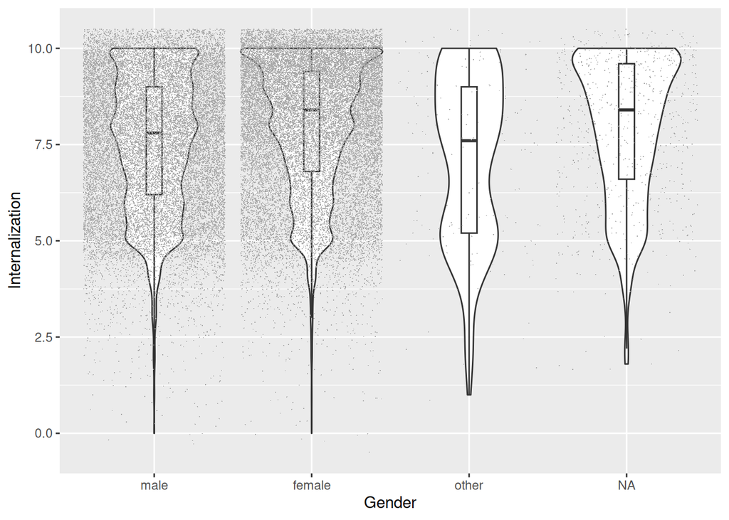

Table 8:

*Symbolization basic descriptives by Gender*

|  | mean | sd | min | max | len |
| --- | --- | --- | --- | --- | --- |
| male | 5.18 | 2.17 | 0.00 | 10.00 | 23205 |
| female | 5.46 | 2.13 | 0.00 | 10.00 | 25138 |
| other | 4.98 | 2.43 | 0.00 | 10.00 | 178 |

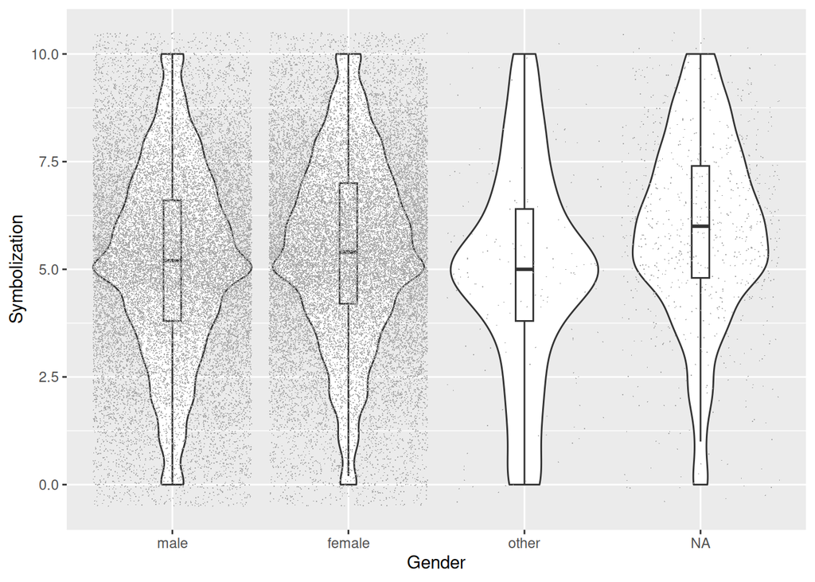

# Predictors (Individual Level Only)

## Internalization

```r
model1 <- lmerTest::lmer(moral_identity_internal ~
                    sex3
                  * age
                  + (1|country)
                , data = x
                , contrasts = list(sex3 = contr.sum, valence = contr.sum )
            )
summary(model1)
```

```
## Linear mixed model fit by REML. t-tests use Satterthwaite's method [
## lmerModLmerTest]
## Formula: moral_identity_internal ~ sex3 * age + (1 | country)
##    Data: x
##
## REML criterion at convergence: 179129.8
##
## Scaled residuals:
##     Min      1Q  Median      3Q     Max
## -5.3557 -0.6954  0.1332  0.7816  2.5731
##
## Random effects:
##  Groups   Name        Variance Std.Dev.
##  country  (Intercept) 0.4359   0.6602
##  Residual             2.6047   1.6139
## Number of obs: 47107, groups:  country, 77
##
## Fixed effects:
##               Estimate Std. Error         df t value Pr(>|t|)
## (Intercept)  7.724e+00  8.016e-02  8.757e+01  96.350  < 2e-16 ***
## sex31       -3.055e-01  2.162e-02  4.705e+04 -14.130  < 2e-16 ***
## age          4.186e-03  5.010e-04  4.710e+04   8.355  < 2e-16 ***
## sex31:age    1.821e-03  4.690e-04  4.704e+04   3.883 0.000103 ***
## ---
## Signif. codes:  0 '***' 0.001 '**' 0.01 '*' 0.05 '.' 0.1 ' ' 1
##
## Correlation of Fixed Effects:
##           (Intr) sex31  age
## sex31      0.020
## age       -0.263 -0.036
## sex31:age -0.010 -0.936  0.005
```

```r
anova(model1)
```

```
## Type III Analysis of Variance Table with Satterthwaite's method
##          Sum Sq Mean Sq NumDF DenDF F value    Pr(>F)
## sex3     520.08  520.08     1 47048 199.668 < 2.2e-16 ***
## age      181.81  181.81     1 47103  69.802 < 2.2e-16 ***
## sex3:age  39.27   39.27     1 47043  15.076 0.0001034 ***
## ---
## Signif. codes:  0 '***' 0.001 '**' 0.01 '*' 0.05 '.' 0.1 ' ' 1
```

## Symbolization

```r
model1 <- lmerTest::lmer(moral_identity_symbolic ~
                    sex3
                  * age
                  + (1|country)
                , data = x
                , contrasts = list(sex3 = contr.sum, valence = contr.sum )
            )
summary(model1)
```

```
## Linear mixed model fit by REML. t-tests use Satterthwaite's method [
## lmerModLmerTest]
## Formula: moral_identity_symbolic ~ sex3 * age + (1 | country)
##    Data: x
##
## REML criterion at convergence: 203078.6
##
## Scaled residuals:
##     Min      1Q  Median      3Q     Max
## -3.3487 -0.6216  0.0428  0.6689  2.9536
##
## Random effects:
##  Groups   Name        Variance Std.Dev.
##  country  (Intercept) 0.530    0.728
##  Residual             4.178    2.044
## Number of obs: 47507, groups:  country, 77
##
## Fixed effects:
##               Estimate Std. Error         df t value Pr(>|t|)
## (Intercept)  5.319e+00  8.981e-02  8.803e+01  59.227  < 2e-16 ***
## sex31       -6.108e-02  2.726e-02  4.745e+04  -2.240  0.02508 *
## age          3.954e-03  6.319e-04  4.749e+04   6.259 3.92e-10 ***
## sex31:age   -1.688e-03  5.915e-04  4.744e+04  -2.853  0.00433 **
## ---
## Signif. codes:  0 '***' 0.001 '**' 0.01 '*' 0.05 '.' 0.1 ' ' 1
##
## Correlation of Fixed Effects:
##           (Intr) sex31  age
## sex31      0.023
## age       -0.296 -0.035
## sex31:age -0.011 -0.936  0.005
```

```r
anova(model1)
```

```
## Type III Analysis of Variance Table with Satterthwaite's method
##           Sum Sq Mean Sq NumDF DenDF F value   Pr(>F)
## sex3      20.970  20.970     1 47452  5.0188 0.025078 *
## age      163.662 163.662     1 47490 39.1691 3.92e-10 ***
## sex3:age  34.021  34.021     1 47445  8.1422 0.004326 **
## ---
## Signif. codes:  0 '***' 0.001 '**' 0.01 '*' 0.05 '.' 0.1 ' ' 1
```

# Predictors (Cultural Variables Included)

## Internalization

```r
model1 <- lmerTest::lmer(moral_identity_internal ~
                    sex3
                    * (age
                    + Power.Distance
                    + Individualism
                    + Masculinity
                    + Uncertainty.Avoidance
                    + Long.Term.Orientation
                    + Indulgence
                    + CTL_C
                    + CTL_DS
                    + CTL_DG)
                  + (1|country)
                , data = x
                , contrasts = list(sex3 = contr.sum, valence = contr.sum )
            )
summary(model1)
```

```
## Linear mixed model fit by REML. t-tests use Satterthwaite's method [
## lmerModLmerTest]
## Formula:
## moral_identity_internal ~ sex3 * (age + Power.Distance + Individualism +
##     Masculinity + Uncertainty.Avoidance + Long.Term.Orientation +
##     Indulgence + CTL_C + CTL_DS + CTL_DG) + (1 | country)
##    Data: x
##
## REML criterion at convergence: 122249.8
##
## Scaled residuals:
##     Min      1Q  Median      3Q     Max
## -5.2882 -0.6852  0.1203  0.7702  2.5242
##
## Random effects:
##  Groups   Name        Variance Std.Dev.
##  country  (Intercept) 0.3213   0.5668
##  Residual             2.6289   1.6214
## Number of obs: 32030, groups:  country, 42
##
## Fixed effects:
##                               Estimate Std. Error         df t value Pr(>|t|)
## (Intercept)                  1.005e+01  9.865e-01  3.157e+01  10.192 1.65e-11
## sex31                       -6.332e-02  1.089e-01  3.199e+04  -0.581  0.56097
## age                          3.096e-03  6.073e-04  3.201e+04   5.098 3.46e-07
## Power.Distance              -4.821e-03  6.875e-03  3.056e+01  -0.701  0.48843
## Individualism               -1.524e-02  7.403e-03  3.192e+01  -2.059  0.04776
## Masculinity                  2.002e-03  4.802e-03  3.040e+01   0.417  0.67966
## Uncertainty.Avoidance       -1.378e-02  6.071e-03  3.114e+01  -2.270  0.03030
## Long.Term.Orientation       -9.252e-03  6.316e-03  3.112e+01  -1.465  0.15299
## Indulgence                  -3.312e-03  6.727e-03  3.061e+01  -0.492  0.62602
## CTL_C                       -1.330e-03  8.868e-03  3.127e+01  -0.150  0.88172
## CTL_DS                      -1.528e-02  6.490e-03  3.070e+01  -2.355  0.02512
## CTL_DG                       1.618e-02  7.112e-03  3.054e+01   2.276  0.03004
## sex31:age                    1.110e-03  5.934e-04  3.198e+04   1.870  0.06154
## sex31:Power.Distance        -5.596e-04  6.683e-04  3.199e+04  -0.837  0.40239
## sex31:Individualism         -3.066e-03  7.532e-04  3.199e+04  -4.071 4.69e-05
## sex31:Masculinity            7.692e-04  4.510e-04  3.199e+04   1.705  0.08814
## sex31:Uncertainty.Avoidance -7.918e-04  6.067e-04  3.200e+04  -1.305  0.19187
## sex31:Long.Term.Orientation -1.160e-03  6.663e-04  3.199e+04  -1.740  0.08178
```

[output cut: 14 more lines]

```
## CTL_C
## CTL_DS                      *
## CTL_DG                      *
## sex31:age                   .
## sex31:Power.Distance
## sex31:Individualism         ***
## sex31:Masculinity           .
## sex31:Uncertainty.Avoidance
## sex31:Long.Term.Orientation .
## sex31:Indulgence
## sex31:CTL_C
## sex31:CTL_DS                **
## sex31:CTL_DG                .
## ---
## Signif. codes:  0 '***' 0.001 '**' 0.01 '*' 0.05 '.' 0.1 ' ' 1
```

```
##
## Correlation matrix not shown by default, as p = 22 > 12.
## Use print(x, correlation=TRUE)  or
##     vcov(x)        if you need it
```

```r
anova(model1)
```

```
## Type III Analysis of Variance Table with Satterthwaite's method
##                            Sum Sq Mean Sq NumDF DenDF F value    Pr(>F)
## sex3                        0.889   0.889     1 31994  0.3380  0.560969
## age                        68.312  68.312     1 32008 25.9848 3.461e-07 ***
## Power.Distance              1.293   1.293     1    31  0.4918  0.488430
## Individualism              11.142  11.142     1    32  4.2383  0.047761 *
## Masculinity                 0.457   0.457     1    30  0.1738  0.679659
## Uncertainty.Avoidance      13.542  13.542     1    31  5.1513  0.030301 *
## Long.Term.Orientation       5.641   5.641     1    31  2.1458  0.152990
## Indulgence                  0.637   0.637     1    31  0.2424  0.626019
## CTL_C                       0.059   0.059     1    31  0.0225  0.881720
## CTL_DS                     14.575  14.575     1    31  5.5442  0.025120 *
## CTL_DG                     13.614  13.614     1    31  5.1784  0.030044 *
## sex3:age                    9.190   9.190     1 31985  3.4958  0.061536 .
## sex3:Power.Distance         1.843   1.843     1 31990  0.7012  0.402389
## sex3:Individualism         43.574  43.574     1 31990 16.5747 4.688e-05 ***
## sex3:Masculinity            7.646   7.646     1 31989  2.9083  0.088137 .
## sex3:Uncertainty.Avoidance  4.478   4.478     1 31995  1.7032  0.191874
## sex3:Long.Term.Orientation  7.964   7.964     1 31988  3.0293  0.081782 .
## sex3:Indulgence             0.007   0.007     1 31990  0.0025  0.960330
## sex3:CTL_C                  0.779   0.779     1 32001  0.2962  0.586301
## sex3:CTL_DS                20.685  20.685     1 31997  7.8683  0.005034 **
## sex3:CTL_DG                 9.187   9.187     1 32007  3.4945  0.061582 .
## ---
## Signif. codes:  0 '***' 0.001 '**' 0.01 '*' 0.05 '.' 0.1 ' ' 1
```

#### (Regular Regression)

```r
fit <- lm(moral_identity_internal ~
                    sex3
                    + age
                    + Power.Distance
                    + Individualism
                    + Masculinity
                    + Uncertainty.Avoidance
                    + Long.Term.Orientation
                    + Indulgence
                    + CTL_C
                    + CTL_DS
                    + CTL_DG
                , data = x
            )

summary(fit)
```

```
##
## Call:
## lm(formula = moral_identity_internal ~ sex3 + age + Power.Distance +
##     Individualism + Masculinity + Uncertainty.Avoidance + Long.Term.Orientation +
##     Indulgence + CTL_C + CTL_DS + CTL_DG, data = x)
##
## Residuals:
##     Min      1Q  Median      3Q     Max
## -8.8381 -1.1894  0.2269  1.3360  3.4769
##
## Coefficients:
##                         Estimate Std. Error t value Pr(>|t|)
## (Intercept)           10.1906046  0.1106901  92.064  < 2e-16 ***
## sex3female             0.4388698  0.0187929  23.353  < 2e-16 ***
## age                    0.0026272  0.0006060   4.335 1.46e-05 ***
## Power.Distance        -0.0063204  0.0006759  -9.351  < 2e-16 ***
## Individualism         -0.0185169  0.0007656 -24.188  < 2e-16 ***
## Masculinity           -0.0001201  0.0004584  -0.262    0.793
## Uncertainty.Avoidance -0.0125040  0.0006116 -20.446  < 2e-16 ***
## Long.Term.Orientation -0.0132368  0.0006783 -19.513  < 2e-16 ***
## Indulgence            -0.0028270  0.0007247  -3.901 9.61e-05 ***
## CTL_C                  0.0043056  0.0009851   4.371 1.24e-05 ***
## CTL_DS                -0.0137766  0.0007465 -18.455  < 2e-16 ***
## CTL_DG                 0.0129235  0.0007802  16.565  < 2e-16 ***
## ---
## Signif. codes:  0 '***' 0.001 '**' 0.01 '*' 0.05 '.' 0.1 ' ' 1
##
## Residual standard error: 1.668 on 32018 degrees of freedom
##   (16313 observations deleted due to missingness)
## Multiple R-squared:  0.08195,    Adjusted R-squared:  0.08164
## F-statistic: 259.8 on 11 and 32018 DF,  p-value: < 2.2e-16
```

## Symbolization

```r
model1 <- lmerTest::lmer(moral_identity_symbolic ~
                    sex3
                    * (age
                    + Power.Distance
                    + Individualism
                    + Masculinity
                    + Uncertainty.Avoidance
                    + Long.Term.Orientation
                    + Indulgence
                    + CTL_C
                    + CTL_DS
                    + CTL_DG)
                  + (1|country)
                , data = x
                , contrasts = list(sex3 = contr.sum, valence = contr.sum )
            )
summary(model1)
```

```
## Linear mixed model fit by REML. t-tests use Satterthwaite's method [
## lmerModLmerTest]
## Formula:
## moral_identity_symbolic ~ sex3 * (age + Power.Distance + Individualism +
##     Masculinity + Uncertainty.Avoidance + Long.Term.Orientation +
##     Indulgence + CTL_C + CTL_DS + CTL_DG) + (1 | country)
##    Data: x
##
## REML criterion at convergence: 138335.7
##
## Scaled residuals:
##     Min      1Q  Median      3Q     Max
## -3.2576 -0.6181  0.0433  0.6643  2.9911
##
## Random effects:
##  Groups   Name        Variance Std.Dev.
##  country  (Intercept) 0.3205   0.5661
##  Residual             4.1786   2.0442
## Number of obs: 32327, groups:  country, 42
##
## Fixed effects:
##                               Estimate Std. Error         df t value Pr(>|t|)
## (Intercept)                  4.820e+00  9.933e-01  3.203e+01   4.853 3.04e-05
## sex31                       -6.941e-01  1.366e-01  3.230e+04  -5.081 3.77e-07
## age                          4.906e-03  7.620e-04  3.230e+04   6.439 1.22e-10
## Power.Distance               9.953e-03  6.896e-03  3.097e+01   1.443 0.159000
## Individualism                9.920e-04  7.461e-03  3.221e+01   0.133 0.895060
## Masculinity                  5.671e-03  4.812e-03  3.059e+01   1.178 0.247720
## Uncertainty.Avoidance       -1.534e-03  6.100e-03  3.128e+01  -0.252 0.803026
## Long.Term.Orientation       -4.093e-03  6.349e-03  3.151e+01  -0.645 0.523745
## Indulgence                   1.195e-02  6.749e-03  3.104e+01   1.771 0.086397
## CTL_C                       -1.622e-02  8.916e-03  3.154e+01  -1.820 0.078324
## CTL_DS                      -8.121e-03  6.513e-03  3.110e+01  -1.247 0.221769
## CTL_DG                       7.328e-03  7.132e-03  3.088e+01   1.028 0.312159
## sex31:age                   -1.370e-03  7.449e-04  3.229e+04  -1.839 0.065869
## sex31:Power.Distance         1.733e-03  8.374e-04  3.229e+04   2.070 0.038471
## sex31:Individualism          2.194e-03  9.455e-04  3.229e+04   2.321 0.020318
## sex31:Masculinity            2.235e-04  5.661e-04  3.229e+04   0.395 0.692987
## sex31:Uncertainty.Avoidance  1.859e-03  7.602e-04  3.230e+04   2.445 0.014475
## sex31:Long.Term.Orientation  6.802e-04  8.363e-04  3.229e+04   0.813 0.416024
```

[output cut: 14 more lines]

```
## CTL_C                       .
## CTL_DS
## CTL_DG
## sex31:age                   .
## sex31:Power.Distance        *
## sex31:Individualism         *
## sex31:Masculinity
## sex31:Uncertainty.Avoidance *
## sex31:Long.Term.Orientation
## sex31:Indulgence            ***
## sex31:CTL_C                 ***
## sex31:CTL_DS                **
## sex31:CTL_DG
## ---
## Signif. codes:  0 '***' 0.001 '**' 0.01 '*' 0.05 '.' 0.1 ' ' 1
```

```
##
## Correlation matrix not shown by default, as p = 22 > 12.
## Use print(x, correlation=TRUE)  or
##     vcov(x)        if you need it
```

```r
anova(model1)
```

```
## Type III Analysis of Variance Table with Satterthwaite's method
##                             Sum Sq Mean Sq NumDF DenDF F value    Pr(>F)
## sex3                       107.893 107.893     1 32297 25.8205 3.768e-07 ***
## age                        173.236 173.236     1 32300 41.4584 1.221e-10 ***
## Power.Distance               8.703   8.703     1    31  2.0829 0.1589999
## Individualism                0.074   0.074     1    32  0.0177 0.8950601
## Masculinity                  5.803   5.803     1    31  1.3887 0.2477200
## Uncertainty.Avoidance        0.264   0.264     1    31  0.0633 0.8030255
## Long.Term.Orientation        1.737   1.737     1    32  0.4157 0.5237454
## Indulgence                  13.104  13.104     1    31  3.1361 0.0863968 .
## CTL_C                       13.835  13.835     1    32  3.3110 0.0783240 .
## CTL_DS                       6.496   6.496     1    31  1.5546 0.2217692
## CTL_DG                       4.412   4.412     1    31  1.0558 0.3121587
## sex3:age                    14.137  14.137     1 32287  3.3833 0.0658688 .
## sex3:Power.Distance         17.903  17.903     1 32293  4.2844 0.0384711 *
## sex3:Individualism          22.501  22.501     1 32293  5.3849 0.0203178 *
## sex3:Masculinity             0.651   0.651     1 32291  0.1559 0.6929871
## sex3:Uncertainty.Avoidance  24.988  24.988     1 32298  5.9800 0.0144746 *
## sex3:Long.Term.Orientation   2.764   2.764     1 32290  0.6615 0.4160235
## sex3:Indulgence            100.646 100.646     1 32294 24.0862 9.257e-07 ***
## sex3:CTL_C                  46.138  46.138     1 32303 11.0416 0.0008919 ***
## sex3:CTL_DS                 38.563  38.563     1 32300  9.2287 0.0023844 **
## sex3:CTL_DG                  4.268   4.268     1 32304  1.0214 0.3121843
## ---
## Signif. codes:  0 '***' 0.001 '**' 0.01 '*' 0.05 '.' 0.1 ' ' 1
```

#### (Regular Regression)

```r
fit <- lm(moral_identity_symbolic ~
                    sex3
                    + age
                    + Power.Distance
                    + Individualism
                    + Masculinity
                    + Uncertainty.Avoidance
                    + Long.Term.Orientation
                    + Indulgence
                    + CTL_C
                    + CTL_DS
                    + CTL_DG
                , data = x
            )

summary(fit)
```

```
##
## Call:
## lm(formula = moral_identity_symbolic ~ sex3 + age + Power.Distance +
##     Individualism + Masculinity + Uncertainty.Avoidance + Long.Term.Orientation +
##     Indulgence + CTL_C + CTL_DS + CTL_DG, data = x)
##
## Residuals:
##     Min      1Q  Median      3Q     Max
## -6.5111 -1.2879  0.0727  1.4097  5.8405
##
## Coefficients:
##                         Estimate Std. Error t value Pr(>|t|)
## (Intercept)            4.3667716  0.1381506  31.609  < 2e-16 ***
## sex3female             0.3200591  0.0234667  13.639  < 2e-16 ***
## age                    0.0064324  0.0007568   8.499  < 2e-16 ***
## Power.Distance         0.0104856  0.0008430  12.438  < 2e-16 ***
## Individualism          0.0052898  0.0009564   5.531 3.21e-08 ***
## Masculinity            0.0038146  0.0005726   6.661 2.75e-11 ***
## Uncertainty.Avoidance -0.0006837  0.0007630  -0.896     0.37
## Long.Term.Orientation -0.0056667  0.0008474  -6.688 2.31e-11 ***
## Indulgence             0.0112388  0.0009054  12.413  < 2e-16 ***
## CTL_C                 -0.0176171  0.0012262 -14.367  < 2e-16 ***
## CTL_DS                -0.0061971  0.0009286  -6.673 2.54e-11 ***
## CTL_DG                 0.0087635  0.0009670   9.062  < 2e-16 ***
## ---
## Signif. codes:  0 '***' 0.001 '**' 0.01 '*' 0.05 '.' 0.1 ' ' 1
##
## Residual standard error: 2.092 on 32315 degrees of freedom
##   (16016 observations deleted due to missingness)
## Multiple R-squared:  0.06104,    Adjusted R-squared:  0.06072
## F-statistic:   191 on 11 and 32315 DF,  p-value: < 2.2e-16
```

# Men and Women Separately

## Men

### Internalization

```r
model1 <- lmerTest::lmer(moral_identity_internal ~
                    age
                    + Power.Distance
                    + Individualism
                    + Masculinity
                    + Uncertainty.Avoidance
                    + Long.Term.Orientation
                    + Indulgence
                    + CTL_C
                    + CTL_DS
                    + CTL_DG
                  + (1|country)
                , data = x
                , contrasts = list(sex3 = contr.sum, valence = contr.sum )
            )
summary(model1)
```

```
## Linear mixed model fit by REML. t-tests use Satterthwaite's method [
## lmerModLmerTest]
## Formula: moral_identity_internal ~ age + Power.Distance + Individualism +
##     Masculinity + Uncertainty.Avoidance + Long.Term.Orientation +
##     Indulgence + CTL_C + CTL_DS + CTL_DG + (1 | country)
##    Data: x
##
## REML criterion at convergence: 60583.3
##
## Scaled residuals:
##     Min      1Q  Median      3Q     Max
## -4.9102 -0.7059  0.0770  0.7750  2.4884
##
## Random effects:
##  Groups   Name        Variance Std.Dev.
##  country  (Intercept) 0.2879   0.5366
##  Residual             2.7056   1.6449
## Number of obs: 15745, groups:  country, 42
##
## Fixed effects:
##                         Estimate Std. Error         df t value Pr(>|t|)
## (Intercept)            1.022e+01  9.503e-01  3.068e+01  10.757  6.2e-12 ***
## age                    4.449e-03  8.765e-04  1.573e+04   5.076  3.9e-07 ***
## Power.Distance        -6.032e-03  6.576e-03  2.955e+01  -0.917  0.36647
## Individualism         -1.971e-02  7.135e-03  3.062e+01  -2.762  0.00963 **
## Masculinity            2.676e-03  4.582e-03  2.895e+01   0.584  0.56371
## Uncertainty.Avoidance -1.506e-02  5.821e-03  2.966e+01  -2.587  0.01485 *
## Long.Term.Orientation -1.176e-02  6.055e-03  2.991e+01  -1.941  0.06167 .
## Indulgence            -4.071e-03  6.437e-03  2.963e+01  -0.633  0.53187
## CTL_C                  7.648e-04  8.514e-03  2.998e+01   0.090  0.92902
## CTL_DS                -1.277e-02  6.224e-03  2.990e+01  -2.051  0.04912 *
## CTL_DG                 1.351e-02  6.818e-03  2.975e+01   1.982  0.05680 .
## ---
## Signif. codes:  0 '***' 0.001 '**' 0.01 '*' 0.05 '.' 0.1 ' ' 1
##
## Correlation of Fixed Effects:
##             (Intr) age    Pwr.Ds Indvdl Msclnt Uncr.A Ln.T.O Indlgn CTL_C
## age         -0.016
## Power.Dstnc -0.694 -0.004
## Individulsm -0.710 -0.012  0.554
## Masculinity  0.059 -0.007 -0.103 -0.299
## Uncrtnty.Av -0.524 -0.018  0.059  0.423 -0.202
## Lng.Trm.Orn -0.271 -0.005  0.014  0.104 -0.116 -0.231
## Indulgence  -0.586 -0.014  0.255  0.352 -0.277  0.213  0.610
## CTL_C        0.181 -0.017  0.169 -0.378  0.390 -0.181 -0.479 -0.557
## CTL_DS      -0.396 -0.010  0.271  0.123 -0.041  0.410 -0.236  0.043  0.057
## CTL_DG       0.225  0.021 -0.433 -0.018 -0.258 -0.176  0.346  0.170 -0.674
##             CTL_DS
## age
## Power.Dstnc
## Individulsm
## Masculinity
## Uncrtnty.Av
## Lng.Trm.Orn
## Indulgence
## CTL_C
## CTL_DS
## CTL_DG      -0.558
```

```r
anova(model1)
```

```
## Type III Analysis of Variance Table with Satterthwaite's method
##                       Sum Sq Mean Sq NumDF   DenDF F value    Pr(>F)
## age                   69.706  69.706     1 15733.1 25.7633 3.904e-07 ***
## Power.Distance         2.276   2.276     1    29.6  0.8412  0.366472
## Individualism         20.638  20.638     1    30.6  7.6278  0.009626 **
## Masculinity            0.923   0.923     1    29.0  0.3411  0.563711
## Uncertainty.Avoidance 18.101  18.101     1    29.7  6.6901  0.014854 *
## Long.Term.Orientation 10.198  10.198     1    29.9  3.7693  0.061674 .
## Indulgence             1.083   1.083     1    29.6  0.4001  0.531874
## CTL_C                  0.022   0.022     1    30.0  0.0081  0.929019
## CTL_DS                11.382  11.382     1    29.9  4.2067  0.049115 *
## CTL_DG                10.627  10.627     1    29.8  3.9277  0.056802 .
## ---
## Signif. codes:  0 '***' 0.001 '**' 0.01 '*' 0.05 '.' 0.1 ' ' 1
```

#### (Regular Regression)

```r
fit <- lm(moral_identity_internal ~
                    age
                    + Power.Distance
                    + Individualism
                    + Masculinity
                    + Uncertainty.Avoidance
                    + Long.Term.Orientation
                    + Indulgence
                    + CTL_C
                    + CTL_DS
                    + CTL_DG
                , data = x
            )

summary(fit)
```

```
##
## Call:
## lm(formula = moral_identity_internal ~ age + Power.Distance +
##     Individualism + Masculinity + Uncertainty.Avoidance + Long.Term.Orientation +
##     Indulgence + CTL_C + CTL_DS + CTL_DG, data = x)
##
## Residuals:
##     Min      1Q  Median      3Q     Max
## -8.5189 -1.2551  0.1682  1.3592  3.5286
##
## Coefficients:
##                         Estimate Std. Error t value Pr(>|t|)
## (Intercept)           10.3411380  0.1658244  62.362  < 2e-16 ***
## age                    0.0039959  0.0008702   4.592 4.43e-06 ***
## Power.Distance        -0.0068955  0.0010115  -6.817 9.61e-12 ***
## Individualism         -0.0213996  0.0011252 -19.019  < 2e-16 ***
## Masculinity           -0.0002224  0.0006721  -0.331  0.74074
## Uncertainty.Avoidance -0.0134787  0.0008964 -15.036  < 2e-16 ***
## Long.Term.Orientation -0.0141312  0.0009662 -14.625  < 2e-16 ***
## Indulgence            -0.0028282  0.0010559  -2.679  0.00740 **
## CTL_C                  0.0038722  0.0014156   2.735  0.00624 **
## CTL_DS                -0.0113675  0.0011157 -10.189  < 2e-16 ***
## CTL_DG                 0.0126686  0.0011773  10.760  < 2e-16 ***
## ---
## Signif. codes:  0 '***' 0.001 '**' 0.01 '*' 0.05 '.' 0.1 ' ' 1
##
## Residual standard error: 1.687 on 15734 degrees of freedom
##   (7460 observations deleted due to missingness)
## Multiple R-squared:  0.0665, Adjusted R-squared:  0.06591
## F-statistic: 112.1 on 10 and 15734 DF,  p-value: < 2.2e-16
```

### Symbolization

```r
model1 <- lmerTest::lmer(moral_identity_symbolic ~
                    age
                    + Power.Distance
                    + Individualism
                    + Masculinity
                    + Uncertainty.Avoidance
                    + Long.Term.Orientation
                    + Indulgence
                    + CTL_C
                    + CTL_DS
                    + CTL_DG
                  + (1|country)
                , data = x
                , contrasts = list(sex3 = contr.sum, valence = contr.sum )
            )
summary(model1)
```

```
## Linear mixed model fit by REML. t-tests use Satterthwaite's method [
## lmerModLmerTest]
## Formula: moral_identity_symbolic ~ age + Power.Distance + Individualism +
##     Masculinity + Uncertainty.Avoidance + Long.Term.Orientation +
##     Indulgence + CTL_C + CTL_DS + CTL_DG + (1 | country)
##    Data: x
##
## REML criterion at convergence: 67968.1
##
## Scaled residuals:
##     Min      1Q  Median      3Q     Max
## -3.1672 -0.6286  0.0493  0.6617  2.9682
##
## Random effects:
##  Groups   Name        Variance Std.Dev.
##  country  (Intercept) 0.3803   0.6166
##  Residual             4.1595   2.0395
## Number of obs: 15891, groups:  country, 42
##
## Fixed effects:
##                         Estimate Std. Error         df t value Pr(>|t|)
## (Intercept)            4.148e+00  1.096e+00  3.202e+01   3.783 0.000642 ***
## age                    3.334e-03  1.081e-03  1.588e+04   3.083 0.002053 **
## Power.Distance         1.285e-02  7.577e-03  3.077e+01   1.696 0.099911 .
## Individualism          1.948e-03  8.232e-03  3.189e+01   0.237 0.814431
## Masculinity            5.491e-03  5.276e-03  3.007e+01   1.041 0.306333
## Uncertainty.Avoidance  1.276e-03  6.708e-03  3.080e+01   0.190 0.850418
## Long.Term.Orientation -4.668e-03  6.980e-03  3.115e+01  -0.669 0.508632
## Indulgence             1.596e-02  7.418e-03  3.089e+01   2.152 0.039324 *
## CTL_C                 -1.803e-02  9.814e-03  3.119e+01  -1.837 0.075757 .
## CTL_DS                -3.453e-03  7.172e-03  3.115e+01  -0.481 0.633545
## CTL_DG                 5.390e-03  7.854e-03  3.095e+01   0.686 0.497595
## ---
## Signif. codes:  0 '***' 0.001 '**' 0.01 '*' 0.05 '.' 0.1 ' ' 1
##
## Correlation of Fixed Effects:
##             (Intr) age    Pwr.Ds Indvdl Msclnt Uncr.A Ln.T.O Indlgn CTL_C
## age         -0.017
## Power.Dstnc -0.694 -0.004
## Individulsm -0.711 -0.013  0.555
## Masculinity  0.060 -0.007 -0.103 -0.299
## Uncrtnty.Av -0.524 -0.019  0.059  0.423 -0.202
## Lng.Trm.Orn -0.273 -0.006  0.015  0.106 -0.117 -0.229
## Indulgence  -0.586 -0.015  0.255  0.353 -0.277  0.213  0.611
## CTL_C        0.182 -0.019  0.167 -0.379  0.390 -0.182 -0.480 -0.557
## CTL_DS      -0.397 -0.011  0.271  0.124 -0.042  0.410 -0.235  0.044  0.056
## CTL_DG       0.225  0.022 -0.433 -0.018 -0.258 -0.176  0.346  0.170 -0.674
##             CTL_DS
## age
## Power.Dstnc
## Individulsm
## Masculinity
## Uncrtnty.Av
## Lng.Trm.Orn
## Indulgence
## CTL_C
## CTL_DS
## CTL_DG      -0.557
```

```r
anova(model1)
```

```
## Type III Analysis of Variance Table with Satterthwaite's method
##                       Sum Sq Mean Sq NumDF   DenDF F value   Pr(>F)
## age                   39.534  39.534     1 15876.7  9.5045 0.002053 **
## Power.Distance        11.970  11.970     1    30.8  2.8777 0.099911 .
## Individualism          0.233   0.233     1    31.9  0.0560 0.814431
## Masculinity            4.505   4.505     1    30.1  1.0830 0.306333
## Uncertainty.Avoidance  0.150   0.150     1    30.8  0.0362 0.850418
## Long.Term.Orientation  1.860   1.860     1    31.1  0.4471 0.508632
## Indulgence            19.264  19.264     1    30.9  4.6313 0.039324 *
## CTL_C                 14.036  14.036     1    31.2  3.3745 0.075757 .
## CTL_DS                 0.964   0.964     1    31.1  0.2318 0.633545
## CTL_DG                 1.960   1.960     1    31.0  0.4711 0.497595
## ---
## Signif. codes:  0 '***' 0.001 '**' 0.01 '*' 0.05 '.' 0.1 ' ' 1
```

#### (Regular Regression)

```r
fit <- lm(moral_identity_symbolic ~
                    age
                    + Power.Distance
                    + Individualism
                    + Masculinity
                    + Uncertainty.Avoidance
                    + Long.Term.Orientation
                    + Indulgence
                    + CTL_C
                    + CTL_DS
                    + CTL_DG
                , data = x
            )

summary(fit)
```

```
##
## Call:
## lm(formula = moral_identity_symbolic ~ age + Power.Distance +
##     Individualism + Masculinity + Uncertainty.Avoidance + Long.Term.Orientation +
##     Indulgence + CTL_C + CTL_DS + CTL_DG, data = x)
##
## Residuals:
##     Min      1Q  Median      3Q     Max
## -6.3570 -1.3177  0.0936  1.4018  5.9026
##
## Coefficients:
##                         Estimate Std. Error t value Pr(>|t|)
## (Intercept)            3.8364668  0.2050671  18.708  < 2e-16 ***
## age                    0.0058044  0.0010775   5.387 7.27e-08 ***
## Power.Distance         0.0125262  0.0012500  10.021  < 2e-16 ***
## Individualism          0.0075074  0.0013930   5.389 7.17e-08 ***
## Masculinity            0.0044539  0.0008323   5.351 8.87e-08 ***
## Uncertainty.Avoidance  0.0007836  0.0011089   0.707  0.47981
## Long.Term.Orientation -0.0052555  0.0011965  -4.392 1.13e-05 ***
## Indulgence             0.0157303  0.0013068  12.037  < 2e-16 ***
## CTL_C                 -0.0204031  0.0017500 -11.659  < 2e-16 ***
## CTL_DS                -0.0043030  0.0013775  -3.124  0.00179 **
## CTL_DG                 0.0087688  0.0014494   6.050 1.48e-09 ***
## ---
## Signif. codes:  0 '***' 0.001 '**' 0.01 '*' 0.05 '.' 0.1 ' ' 1
##
## Residual standard error: 2.098 on 15880 degrees of freedom
##   (7314 observations deleted due to missingness)
## Multiple R-squared:  0.06688,    Adjusted R-squared:  0.06629
## F-statistic: 113.8 on 10 and 15880 DF,  p-value: < 2.2e-16
```

## Women

### Internalization

```r
model1 <- lmerTest::lmer(moral_identity_internal ~
                    age
                    + Power.Distance
                    + Individualism
                    + Masculinity
                    + Uncertainty.Avoidance
                    + Long.Term.Orientation
                    + Indulgence
                    + CTL_C
                    + CTL_DS
                    + CTL_DG
                  + (1|country)
                , data = x
                , contrasts = list(sex3 = contr.sum, valence = contr.sum )
            )
summary(model1)
```

```
## Linear mixed model fit by REML. t-tests use Satterthwaite's method [
## lmerModLmerTest]
## Formula: moral_identity_internal ~ age + Power.Distance + Individualism +
##     Masculinity + Uncertainty.Avoidance + Long.Term.Orientation +
##     Indulgence + CTL_C + CTL_DS + CTL_DG + (1 | country)
##    Data: x
##
## REML criterion at convergence: 61638.6
##
## Scaled residuals:
##     Min      1Q  Median      3Q     Max
## -5.3731 -0.6729  0.1632  0.7863  2.2676
##
## Random effects:
##  Groups   Name        Variance Std.Dev.
##  country  (Intercept) 0.3655   0.6045
##  Residual             2.5403   1.5938
## Number of obs: 16285, groups:  country, 42
##
## Fixed effects:
##                         Estimate Std. Error         df t value Pr(>|t|)
## (Intercept)            9.872e+00  1.062e+00  3.086e+01   9.295 1.86e-10 ***
## age                    1.718e-03  8.461e-04  1.627e+04   2.031   0.0423 *
## Power.Distance        -3.578e-03  7.370e-03  2.984e+01  -0.485   0.6309
## Individualism         -1.075e-02  7.982e-03  3.107e+01  -1.347   0.1879
## Masculinity            1.404e-03  5.140e-03  2.941e+01   0.273   0.7867
## Uncertainty.Avoidance -1.210e-02  6.519e-03  3.011e+01  -1.857   0.0732 .
## Long.Term.Orientation -7.199e-03  6.792e-03  3.046e+01  -1.060   0.2975
## Indulgence            -2.748e-03  7.214e-03  2.994e+01  -0.381   0.7059
## CTL_C                 -2.272e-03  9.537e-03  3.047e+01  -0.238   0.8133
## CTL_DS                -1.780e-02  6.957e-03  2.992e+01  -2.559   0.0158 *
## CTL_DG                 1.807e-02  7.617e-03  2.970e+01   2.373   0.0243 *
## ---
## Signif. codes:  0 '***' 0.001 '**' 0.01 '*' 0.05 '.' 0.1 ' ' 1
##
## Correlation of Fixed Effects:
##             (Intr) age    Pwr.Ds Indvdl Msclnt Uncr.A Ln.T.O Indlgn CTL_C
## age         -0.017
## Power.Dstnc -0.694 -0.003
## Individulsm -0.710 -0.010  0.556
## Masculinity  0.057 -0.002 -0.102 -0.298
## Uncrtnty.Av -0.521 -0.008  0.055  0.419 -0.200
## Lng.Trm.Orn -0.270 -0.006  0.015  0.102 -0.114 -0.234
## Indulgence  -0.586 -0.008  0.253  0.352 -0.277  0.211  0.611
## CTL_C        0.179 -0.011  0.168 -0.376  0.389 -0.181 -0.477 -0.557
## CTL_DS      -0.391 -0.012  0.266  0.120 -0.039  0.407 -0.238  0.040  0.056
## CTL_DG       0.223  0.016 -0.430 -0.018 -0.259 -0.173  0.345  0.171 -0.675
##             CTL_DS
## age
## Power.Dstnc
## Individulsm
## Masculinity
## Uncrtnty.Av
## Lng.Trm.Orn
## Indulgence
## CTL_C
## CTL_DS
## CTL_DG      -0.555
```

```r
anova(model1)
```

```
## Type III Analysis of Variance Table with Satterthwaite's method
##                        Sum Sq Mean Sq NumDF   DenDF F value  Pr(>F)
## age                   10.4772 10.4772     1 16272.7  4.1244 0.04228 *
## Power.Distance         0.5987  0.5987     1    29.8  0.2357 0.63089
## Individualism          4.6059  4.6059     1    31.1  1.8131 0.18787
## Masculinity            0.1895  0.1895     1    29.4  0.0746 0.78665
## Uncertainty.Avoidance  8.7557  8.7557     1    30.1  3.4468 0.07319 .
## Long.Term.Orientation  2.8539  2.8539     1    30.5  1.1234 0.29751
## Indulgence             0.3686  0.3686     1    29.9  0.1451 0.70594
## CTL_C                  0.1442  0.1442     1    30.5  0.0568 0.81330
## CTL_DS                16.6312 16.6312     1    29.9  6.5470 0.01581 *
## CTL_DG                14.3021 14.3021     1    29.7  5.6301 0.02433 *
## ---
## Signif. codes:  0 '***' 0.001 '**' 0.01 '*' 0.05 '.' 0.1 ' ' 1
```

#### (Regular Regression)

```r
fit <- lm(moral_identity_internal ~
                    age
                    + Power.Distance
                    + Individualism
                    + Masculinity
                    + Uncertainty.Avoidance
                    + Long.Term.Orientation
                    + Indulgence
                    + CTL_C
                    + CTL_DS
                    + CTL_DG
                , data = x
            )

summary(fit)
```

```
##
## Call:
## lm(formula = moral_identity_internal ~ age + Power.Distance +
##     Individualism + Masculinity + Uncertainty.Avoidance + Long.Term.Orientation +
##     Indulgence + CTL_C + CTL_DS + CTL_DG, data = x)
##
## Residuals:
##     Min      1Q  Median      3Q     Max
## -8.7241 -1.0975  0.2935  1.3192  2.9729
##
## Coefficients:
##                         Estimate Std. Error t value Pr(>|t|)
## (Intercept)           10.4402245  0.1470066  71.019  < 2e-16 ***
## age                    0.0014623  0.0008463   1.728 0.084034 .
## Power.Distance        -0.0056634  0.0009133  -6.201 5.75e-10 ***
## Individualism         -0.0156475  0.0010457 -14.963  < 2e-16 ***
## Masculinity            0.0001709  0.0006283   0.272 0.785628
## Uncertainty.Avoidance -0.0113971  0.0008472 -13.452  < 2e-16 ***
## Long.Term.Orientation -0.0122908  0.0009541 -12.882  < 2e-16 ***
## Indulgence            -0.0026745  0.0009989  -2.678 0.007423 **
## CTL_C                  0.0051343  0.0013780   3.726 0.000195 ***
## CTL_DS                -0.0164396  0.0010199 -16.118  < 2e-16 ***
## CTL_DG                 0.0129158  0.0010504  12.297  < 2e-16 ***
## ---
## Signif. codes:  0 '***' 0.001 '**' 0.01 '*' 0.05 '.' 0.1 ' ' 1
##
## Residual standard error: 1.647 on 16274 degrees of freedom
##   (8853 observations deleted due to missingness)
## Multiple R-squared:  0.06697,    Adjusted R-squared:  0.0664
## F-statistic: 116.8 on 10 and 16274 DF,  p-value: < 2.2e-16
```

### Symbolization

```r
model1 <- lmerTest::lmer(moral_identity_symbolic ~
                    age
                    + Power.Distance
                    + Individualism
                    + Masculinity
                    + Uncertainty.Avoidance
                    + Long.Term.Orientation
                    + Indulgence
                    + CTL_C
                    + CTL_DS
                    + CTL_DG
                  + (1|country)
                , data = x
                , contrasts = list(sex3 = contr.sum, valence = contr.sum )
            )
summary(model1)
```

```
## Linear mixed model fit by REML. t-tests use Satterthwaite's method [
## lmerModLmerTest]
## Formula: moral_identity_symbolic ~ age + Power.Distance + Individualism +
##     Masculinity + Uncertainty.Avoidance + Long.Term.Orientation +
##     Indulgence + CTL_C + CTL_DS + CTL_DG + (1 | country)
##    Data: x
##
## REML criterion at convergence: 70325.9
##
## Scaled residuals:
##     Min      1Q  Median      3Q     Max
## -3.1883 -0.6052  0.0358  0.6694  2.8358
##
## Random effects:
##  Groups   Name        Variance Std.Dev.
##  country  (Intercept) 0.2952   0.5434
##  Residual             4.1695   2.0419
## Number of obs: 16436, groups:  country, 42
##
## Fixed effects:
##                         Estimate Std. Error         df t value Pr(>|t|)
## (Intercept)            5.204e+00  9.720e-01  3.201e+01   5.354 7.08e-06 ***
## age                    6.090e-03  1.078e-03  1.641e+04   5.647 1.66e-08 ***
## Power.Distance         8.326e-03  6.703e-03  3.075e+01   1.242   0.2236
## Individualism          1.352e-03  7.309e-03  3.199e+01   0.185   0.8544
## Masculinity            5.654e-03  4.658e-03  2.988e+01   1.214   0.2344
## Uncertainty.Avoidance -2.256e-03  5.932e-03  3.067e+01  -0.380   0.7064
## Long.Term.Orientation -3.842e-03  6.202e-03  3.158e+01  -0.619   0.5400
## Indulgence             8.387e-03  6.567e-03  3.099e+01   1.277   0.2111
## CTL_C                 -1.335e-02  8.701e-03  3.138e+01  -1.535   0.1349
## CTL_DS                -1.088e-02  6.330e-03  3.090e+01  -1.719   0.0957 .
## CTL_DG                 6.950e-03  6.918e-03  3.051e+01   1.005   0.3230
## ---
## Signif. codes:  0 '***' 0.001 '**' 0.01 '*' 0.05 '.' 0.1 ' ' 1
##
## Correlation of Fixed Effects:
##             (Intr) age    Pwr.Ds Indvdl Msclnt Uncr.A Ln.T.O Indlgn CTL_C
## age         -0.023
## Power.Dstnc -0.694 -0.005
## Individulsm -0.715 -0.014  0.557
## Masculinity  0.060 -0.002 -0.102 -0.297
## Uncrtnty.Av -0.519 -0.012  0.053  0.419 -0.201
## Lng.Trm.Orn -0.280 -0.009  0.022  0.115 -0.117 -0.228
## Indulgence  -0.588 -0.011  0.257  0.356 -0.277  0.211  0.613
## CTL_C        0.188 -0.015  0.162 -0.381  0.390 -0.181 -0.483 -0.557
## CTL_DS      -0.393 -0.017  0.268  0.126 -0.044  0.404 -0.229  0.044  0.047
## CTL_DG       0.220  0.022 -0.429 -0.018 -0.259 -0.172  0.344  0.170 -0.674
##             CTL_DS
## age
## Power.Dstnc
## Individulsm
## Masculinity
## Uncrtnty.Av
## Lng.Trm.Orn
## Indulgence
## CTL_C
## CTL_DS
## CTL_DG      -0.548
```

```r
anova(model1)
```

```
## Type III Analysis of Variance Table with Satterthwaite's method
##                        Sum Sq Mean Sq NumDF   DenDF F value    Pr(>F)
## age                   132.981 132.981     1 16414.6 31.8938 1.655e-08 ***
## Power.Distance          6.433   6.433     1    30.8  1.5428   0.22359
## Individualism           0.143   0.143     1    32.0  0.0342   0.85440
## Masculinity             6.142   6.142     1    29.9  1.4731   0.23436
## Uncertainty.Avoidance   0.603   0.603     1    30.7  0.1446   0.70638
## Long.Term.Orientation   1.600   1.600     1    31.6  0.3838   0.54004
## Indulgence              6.800   6.800     1    31.0  1.6310   0.21105
## CTL_C                   9.818   9.818     1    31.4  2.3548   0.13492
## CTL_DS                 12.316  12.316     1    30.9  2.9540   0.09567 .
## CTL_DG                  4.207   4.207     1    30.5  1.0091   0.32302
## ---
## Signif. codes:  0 '***' 0.001 '**' 0.01 '*' 0.05 '.' 0.1 ' ' 1
```

#### (Regular Regression)

```r
fit <- lm(moral_identity_symbolic ~
                    age
                    + Power.Distance
                    + Individualism
                    + Masculinity
                    + Uncertainty.Avoidance
                    + Long.Term.Orientation
                    + Indulgence
                    + CTL_C
                    + CTL_DS
                    + CTL_DG
                , data = x
            )

summary(fit)
```

```
##
## Call:
## lm(formula = moral_identity_symbolic ~ age + Power.Distance +
##     Individualism + Masculinity + Uncertainty.Avoidance + Long.Term.Orientation +
##     Indulgence + CTL_C + CTL_DS + CTL_DG, data = x)
##
## Residuals:
##     Min      1Q  Median      3Q     Max
## -6.3495 -1.2642  0.0475  1.4204  5.3698
##
## Coefficients:
##                         Estimate Std. Error t value Pr(>|t|)
## (Intercept)            5.1282796  0.1851845  27.693  < 2e-16 ***
## age                    0.0069406  0.0010662   6.510 7.75e-11 ***
## Power.Distance         0.0088575  0.0011498   7.704 1.40e-14 ***
## Individualism          0.0033452  0.0013184   2.537   0.0112 *
## Masculinity            0.0033346  0.0007919   4.211 2.56e-05 ***
## Uncertainty.Avoidance -0.0018877  0.0010660  -1.771   0.0766 .
## Long.Term.Orientation -0.0061664  0.0012023  -5.129 2.95e-07 ***
## Indulgence             0.0072922  0.0012593   5.791 7.14e-09 ***
## CTL_C                 -0.0144663  0.0017267  -8.378  < 2e-16 ***
## CTL_DS                -0.0077286  0.0012779  -6.048 1.50e-09 ***
## CTL_DG                 0.0081922  0.0013110   6.249 4.24e-10 ***
## ---
## Signif. codes:  0 '***' 0.001 '**' 0.01 '*' 0.05 '.' 0.1 ' ' 1
##
## Residual standard error: 2.084 on 16425 degrees of freedom
##   (8702 observations deleted due to missingness)
## Multiple R-squared:  0.04671,    Adjusted R-squared:  0.04613
## F-statistic: 80.49 on 10 and 16425 DF,  p-value: < 2.2e-16
```